# Vignette 1 - Getting started

Dr Annie Visser-Quinn (a.visser-quinn@hw.ac.uk)

2021-01-07

## 1. Introduction

If you’ve not done so already, you can install OSMtidy using the package devtools: `devtools::install_github("avisserquinn/OSMtidy")`.

This vignette provides an example of how to prepare a shapefile for use in OSMtidy. If you don’t have a shapefile, OSMtidy includes example data from the UK’s Ordnance Survey.

## 2. Example data

The example data is a shapefile of wards across the UK. The data is from the UK’s Ordinance Survey Open Data (https://www.ordnancesurvey.co.uk/business-government/products/boundaryline) and is made available under the UK Government’s OGL licence; see http://www.nationalarchives.gov.uk/doc/open-government-licence/version/3/ for details.

Access the file path of the example data with the code below.

```r
files <-
  system.file("extdata", "", package = "OSMtidy") %>%
  list.files(pattern = "district_borough_unitary_ward_region", full.names = TRUE)
files
```

```
## [1] "C:/Users/av57/Documents/R/win-library/4.0/OSMtidy/extdata/district_borough_unitary_ward_region.dbf"
## [2] "C:/Users/av57/Documents/R/win-library/4.0/OSMtidy/extdata/district_borough_unitary_ward_region.prj"
## [3] "C:/Users/av57/Documents/R/win-library/4.0/OSMtidy/extdata/district_borough_unitary_ward_region.shp"
## [4] "C:/Users/av57/Documents/R/win-library/4.0/OSMtidy/extdata/district_borough_unitary_ward_region.shx"
```

## 3. Reading in a shapefile

You can read in a shapefile to R using a function from the R package sf, `st_read()`. As a dependency of OSMtidy, sf should already be installed and loaded.

If using the example data, you can use the filepath saved above. Alternatively, you can paste the filepath in as a string, e.g. `"myShapefile.shp"`.

```r
shp
```

```
## Simple feature collection with 808 features and 15 fields
## geometry type:  MULTIPOLYGON
## dimension:      XY
## bbox:           xmin: 250424.5 ymin: 155850.8 xmax: 561957.5 ymax: 868195.6
## projected CRS:  OSGB 1936 / British National Grid
## First 10 features:
##                                   NAME AREA_CODE          DESCRIPTIO
## 1             New Addington North Ward       LBW London Borough Ward
## 2                        Selhurst Ward       LBW London Borough Ward
## 3                        Woodside Ward       LBW London Borough Ward
## 4                  Thornton Heath Ward       LBW London Borough Ward
## 5  Crystal Palace & Upper Norwood Ward       LBW London Borough Ward
## 6                          Darwin Ward       LBW London Borough Ward
## 7            Hayes and Coney Hall Ward       LBW London Borough Ward
## 8       Bromley Common and Keston Ward       LBW London Borough Ward
```

[output cut: 35 more lines]

## 4. Tidying the shapefile

In the next code chunk, we reduce the data down to the location of interest using tidyverse notation.

```r
shp <-
  shp %>%
  filter(str_detect(FILE_NAME, "CITY_OF_EDINBURGH")) %>%
  filter(str_detect(NAME, "Leith Walk")) %>%
  select(geometry)
shp
```

```
## Simple feature collection with 1 feature and 0 fields
## geometry type:  MULTIPOLYGON
## dimension:      XY
## bbox:           xmin: 325186.8 ymin: 674419.7 xmax: 327500.8 ymax: 676416
## projected CRS:  OSGB 1936 / British National Grid
##                         geometry
## 1 MULTIPOLYGON (((327500.8 67...
```

Because the shapefile was imported to R as a spatial feature, using sf, we can plot it in ggplot using `geom_sf()`.

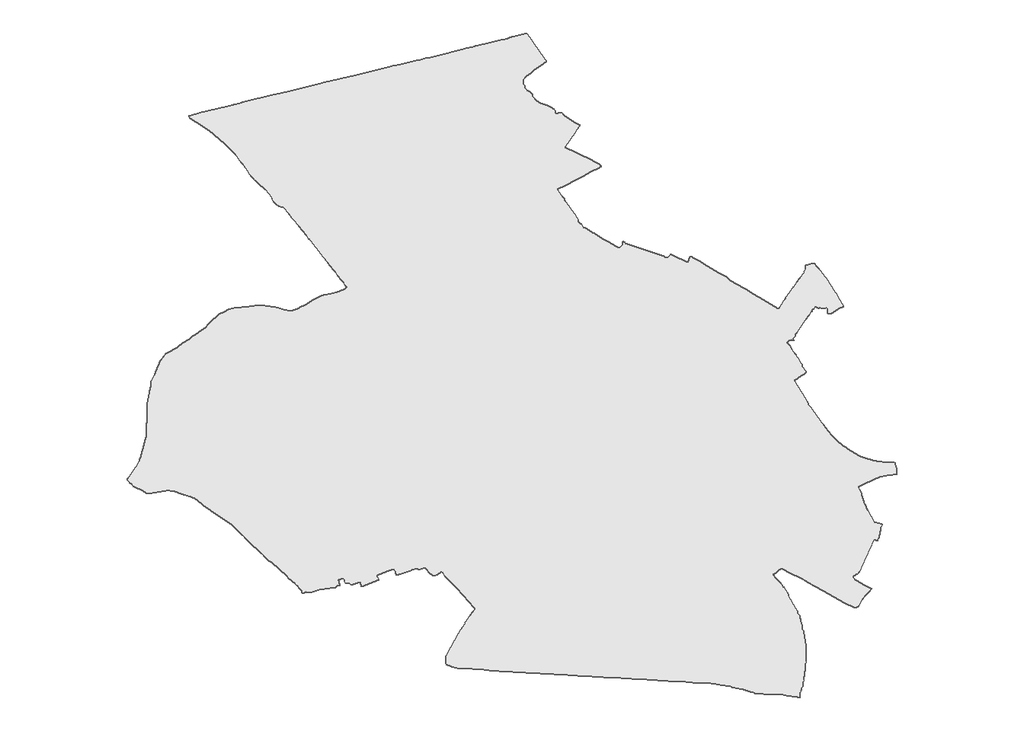

```r
shp %>%
  ggplot() +
  geom_sf() +
  theme_void()
```

You can simplify the jagged outlines of the ward using `st_simplify()`. The final step is to transform the projection to EPSG:4326 (https://epsg.io/4326) using `st_transform()`.

```r
shp <-
  shp %>%
  st_simplify(dTolerance = 25) %>%
  st_transform(4326)
shp
```

```
## Simple feature collection with 1 feature and 0 fields
## geometry type:  POLYGON
## dimension:      XY
## bbox:           xmin: -3.199973 ymin: 55.95726 xmax: -3.162921 ymax: 55.97507
## geographic CRS: WGS 84
##                         geometry
## 1 POLYGON ((-3.162921 55.9633...
```

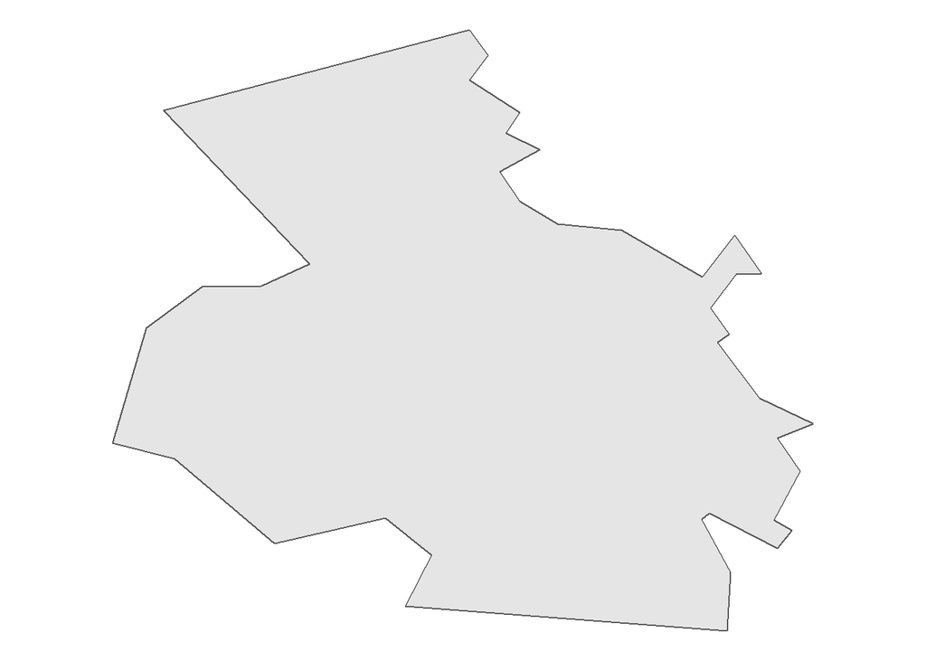

```r
shp %>%
  ggplot() +
  geom_sf() +
  theme_void()
```

## 5. Export the shapefile

The shapefile is now ready for use in OSMtidy. Shapefiles can be exported using the sf function `st_write()`.

```r
shp %>%
  st_write("exampleEdinburgh.shp",
           delete_dsn = TRUE,
           delete_layer = TRUE,
           quiet = TRUE)
```

Now you’re ready to run OSMtidy! See Vignette 2 for a general walkthrough of the OSMtidy workflow.